# The Hispanic Paradox

Patrick Wu

3/3/2022

In this blog post, I will examine the Hispanic Paradox, the evidence supporting its existence, and potential explanations. This educational resource is intended for medical students, clinicians, and members of interdisciplinary teams. In this post, Hispanics are ethnically diverse individuals in the US who identify as “Hispanic” or “Latino.”[1]

## What is the Hispanic Paradox?

When compared to their Non-Hispanic White (NHW) counterparts in the US, Hispanics generally come from lower socioeconomic backgrounds and have higher rates of diseases like diabetes and obesity. Despite these disadvantages, Hispanics live longer than NHWs, a finding that is known as the Hispanic Paradox.[2] For example, in 2018, Hispanics had a longer life expectancy than NHWs (80.7 vs. 78.4 years; Figure 1).[3]

[figure not shown]

**Figure 1**: Life expectancy at birth in years, by race/ethnicity, 2008-2018.

However, a 2013 meta-analysis found that the Hispanic Paradox does not apply across all diseases. For example, when compared to NHWs, Hispanics had lower mortality rates due to cardiovascular disease (CVD), but had similar mortality rates in cancer and HIV/AIDS (Figure 2).[4]

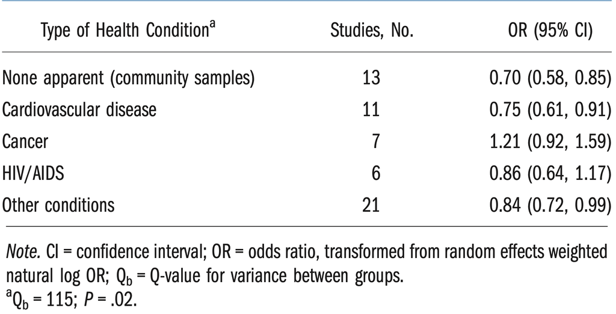

**Figure 2**: Effect sizes of mortality risk stratified by disease types. Odds ratio (OR) < 1 indicates a survival advantage for Hispanics compared to NHWs. OR > 1 indicates a survival advantage for NHWs compared to Hispanics.

Given the particularly large survival advantage for Hispanics in CVD, the next section highlights a few key studies that have compared CVD mortality rates between Hispanics and NHWs.

## What studies have demonstrated the Hispanic survival advantage for CVD?

In the earlier meta-analysis, one of the included papers re-examined data from the International Verapamil-Trandolapril Study (INVEST).[5] This meta-analysis found that Hispanics with CVD lived longer than NHWs, reporting an odds ratio (OR) with 95% confidence interval (CI) of 0.63 [0.56, 0.70]. This statistic is consistent with the raw data provided in the original study; after 3 years of follow-up, 5.8% (468/8045) of Hispanics and 8.9% (1298/14531) of NHWs had died. However, the Hispanic and NHWs cohorts varied in many important characteristics like age; Hispanics were younger than NHWs, with mean (SD) ages of 65.7 (9.8) and 66.3 (9.7), respectively. To control for these differences, the authors used a Cox proportional hazards model adjusting for confounders like age and comorbidities. After adjusting for these confounders, the authors did not find a significant difference in mortality rate between Hispanics and NHWs, reporting a hazard ratio (HR) 95% CI of 0.98 [0.88, 1.10].

In 2017, a study compared CVD mortality rates among the NHWs and the 3 largest US Hispanic subgroups (Mexicans, Puerto Ricans, and Cubans). This study used mortality data from the US National Center for Health Statistics collected between 2003 and 2012.[6] Overall, Hispanics had lower age-adjusted CVD mortality rates compared to NHWs. Lower CVD mortality rates were seen in both males (age-adjusted mortality rates per 100,000 population: Hispanic 350.8 vs. 465.5) and females (age-adjusted mortality rates per 100,000 population: Hispanic 247.9 vs. 321.9). The authors also found differences in CVD mortality rates among the Hispanic subgroups. In both males and females, Mexicans had the lowest CVD mortality rate and Puerto Ricans had the highest CVD mortality rate (Table 1).

**Table 1:** Age-Adjusted Mortality Rates per 100,000 Population for Non-Hispanic White, All Hispanic, Hispanic Subgroup populations.

| Sex | Non-Hispanic White | All Hispanics | Mexican | Cuban | Puerto Rican |
| --- | --- | --- | --- | --- | --- |
| Male | 465.5 | 350.8 | 354.7 | 412.0 | 438.5 |
| Female | 321.9 | 247.9 | 261.6 | 266.1 | 302.2 |

## What are potential explanations for the Hispanic survival advantage?

Like many findings in medicine, the Hispanic survival advantage is likely multifactorial. In terms of biological factors, a reasonable hypothesis is that Hispanics have genetic variations that allow them to live longer. For example, a study in 2016 compared the genetic ancestries of 6 self-identified Hispanic subgroups: Cuban, Dominican, Puerto Rican, Mexican, Central American, and South American.[7] Among these subgroups, there were large differences in genetic ancestries, which correlate with the sizes of CVD survival advantage in the Rodriguez et al. paper highlighted above.[6] The 2016 genetic study found that Mexicans had higher proportion of “American” ancestry, compared to Puerto Ricans and Cubans. On the contrary, Puerto Ricans and Cubans had higher proportions of “European” genetic ancestry (Figure 3). These genetic findings are consistent with the survival advantages seen in the Rodriguez et al. study, in which Mexicans have the lowest CVD mortality rates among the Hispanic subgroups (Table 1).[6] These results suggest that genetic variants in the “American” ancestry may protect individuals from CVD death.

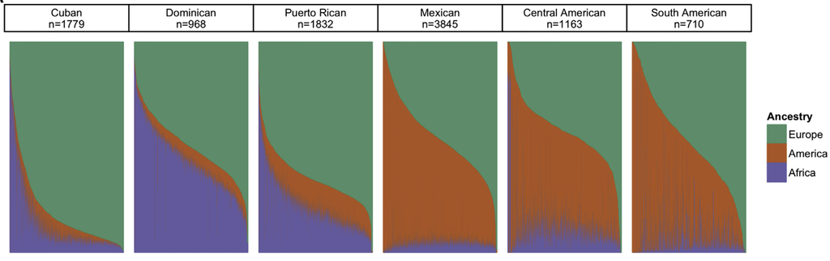

**Figure 3**: Estimates of autosomal continental ancestry proportion in unrelated individuals. The six Hispanic subgroups are self-identified. Each column represents a single individual, and the three color-coded segments represent the three ancestry fractions. Numbers found on top of each subgraph represent the count of individuals in the each Hispanic subgroup

In terms of non-biological factors, cultural differences have been considered.[8] For example, studies suggest that compared to NHWs, Hispanic individuals generally have stronger familial and informal support networks, assistance from which could help older Hispanics maintain their health at home. This hypothesis is supported in part by studies that have shown that Mexicans living in high-density Mexican-American neighborhoods have lower all-cause mortality rates.[9]

## What are potential confounding factors?

One potential confounding factor that may inflate magnitude of the Hispanic Paradox is the “salmon bias,” in which Hispanic immigrants return to their home country in older age, so that they die in their country of origin instead of the US.[1] However, a reasonable argument against this hypothesis is that a survival advantage is seen in the Cubans, individuals who are unlikely to return to Cuba due to political reasons. Further, Puerto Ricans also have a survival advantage compared to NHWs, but their deaths in Puerto Rico would be recorded in US mortality data, as Puerto Rico is a US territory.[10]

## References

1.

Daviglus ML, Pirzada A, Stamler J. Challenges in assessing cardiovascular mortality among Hispanic/Latino groups in the united states. JAMA Cardiol. 2017;2: 248–249. doi:10.1001/jamacardio.2016.5018

2.

Markides KS, Coreil J. The health of hispanics in the southwestern united states: An epidemiologic paradox. Public Health Rep. 1986;101: 253–265. Available: https://www.ncbi.nlm.nih.gov/pubmed/3086917

3.

Life expectancy. https://www.healthsystemtracker.org/indicator/health-well-being/life-expectancy/; Available: https://www.healthsystemtracker.org/indicator/health-well-being/life-expectancy/

4.

Ruiz JM, Steffen P, Smith TB. Hispanic mortality paradox: A systematic review and meta-analysis of the longitudinal literature. Am J Public Health. 2013;103: e52–60. doi:10.2105/AJPH.2012.301103

5.

Cooper-DeHoff RM, Aranda JM Jr, Gaxiola E, Cangiano JL, Garcia-Barreto D, Conti CR, et al. Blood pressure control and cardiovascular outcomes in high-risk hispanic patients–findings from the international verapamil SR/Trandolapril study (INVEST). Am Heart J. 2006;151: 1072–1079. doi:10.1016/j.ahj.2005.05.024

6.

Rodriguez F, Hastings KG, Boothroyd DB, Echeverria S, Lopez L, Cullen M, et al. Disaggregation of Cause-Specific cardiovascular disease mortality among hispanic subgroups. JAMA Cardiol. 2017;2: 240–247. doi:10.1001/jamacardio.2016.4653

7.

Conomos MP, Laurie CA, Stilp AM, Gogarten SM, McHugh CP, Nelson SC, et al. Genetic diversity and association studies in US Hispanic/Latino populations: Applications in the hispanic community health Study/Study of latinos. Am J Hum Genet. 2016;98: 165–184. doi:10.1016/j.ajhg.2015.12.001

8.

Gallo LC, Penedo FJ, Espinosa de los Monteros K, Arguelles W. Resiliency in the face of disadvantage: Do hispanic cultural characteristics protect health outcomes? J Pers. 2009;77: 1707–1746. doi:10.1111/j.1467-6494.2009.00598.x

9.

Eschbach K, Ostir GV, Patel KV, Markides KS, Goodwin JS. Neighborhood context and mortality among older mexican americans: Is there a barrio advantage? Am J Public Health. 2004;94: 1807–1812. doi:10.2105/ajph.94.10.1807

10.

Abraı́do-Lanza AF, Dohrenwend BP, Ng-Mak DS, Turner JB. The latino mortality paradox: A test of the “salmon bias” and healthy migrant hypotheses. Am J Public Health. 1999;89: 1543–1548. doi:10.2105/ajph.89.10.1543